# repeated_measures_anova

PR

2025-04-08

### Purpose

This markdown documents the workflow for calculating statistics for differences between plots for time-series datasets collected by sensors before/during/after the TEMPEST2 event.

This all started which I naively thought I could just apply Tukey’s HSD to time-series to compare between different time-periods, like this:

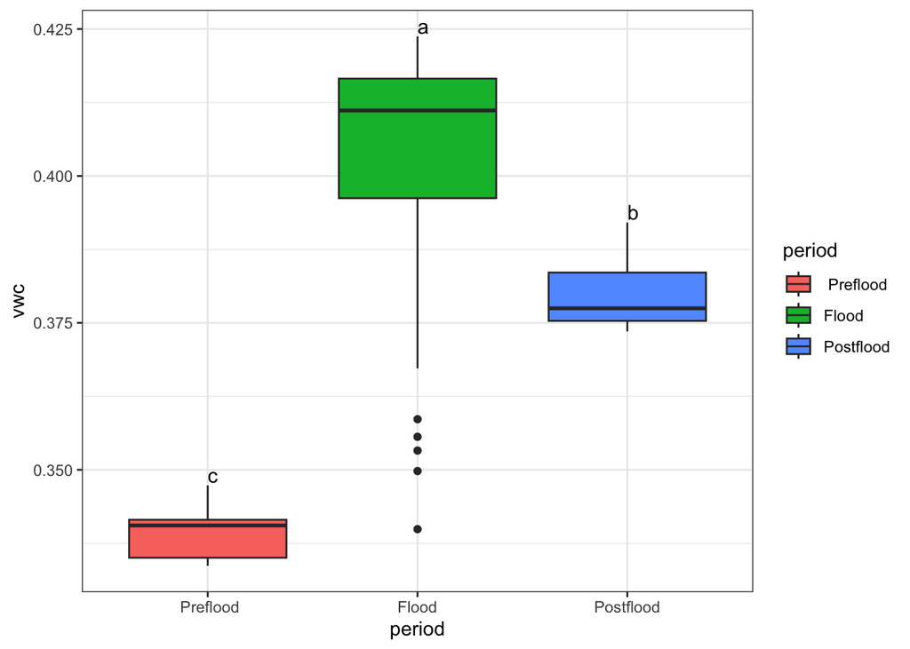

Nice, simple, easy, and super violating of all assumptions. Crap.

To get back to this level of statistical understanding while making sure our data meet the assumptions of the statistical tests we use, let’s go on a journey. My goal: statistical significance (p-values) to compare how different periods relative to the flooding event compare.

### Decision #1 - how to define our periods

ANOVAs have three key assumptions:

1. Data are normally distributed
2. Groups have homogeneous variances
3. Data are independent

For VWC in Freshwater at 5 cm:

```
## [1] "Shapiro-Wilk p-value: 4.36522244575906e-19"
```

```
## [1] "Levene's p-value: 3.5824707732053e-63"
```

Shapiro-Wilk p<0.05 rejects the assumption that the data are normally distributed Levene’s p<0.05 rejects the assumption that variance is homogenous between groups

[figure not shown]

Icing on the cake - time-series are not independent:

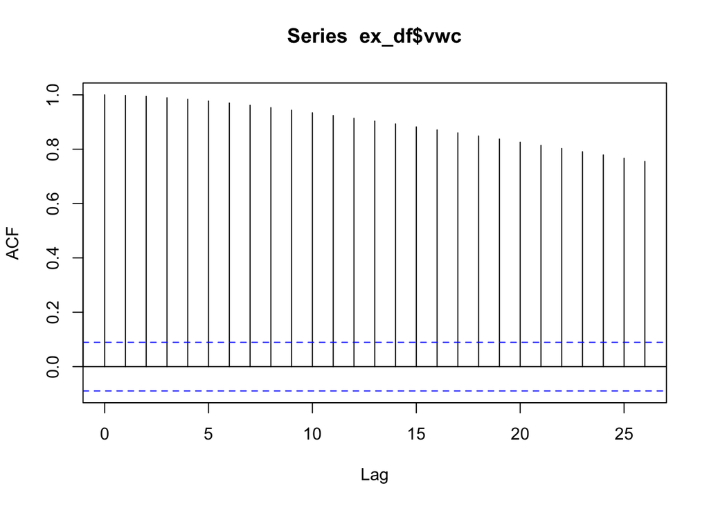

*So we violated all ANOVA assumptions. What can we do?*

There are lots of non-parametric statistics for normality and homogeneity of variance assumptions, addressing the independence issue is trickier.

### Decision #2 - Repeated measures ANOVA

Repeated measures can be used address auto-correlation in datasets. I did not find a satisfactory solution for how this could be applied to different periods of one time-series, but it can be applied if time is your repeated measure ACROSS different time-series collected at the same time. So, instead of comparing pre-flood to flood, we can compare between plots for pre-flood, etc (comparisons are dashed vertical lines below):

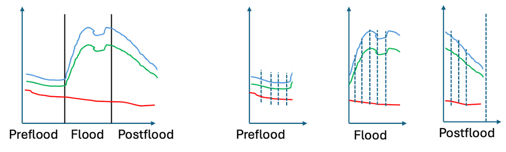

Let’s impelement an ANOVA for pre-flood data for VWC, which we would assume is not significantly different, but it turns out it is…

```
## Anova Table (Type 3 tests)
##
## Response: vwc
##   Effect           df  MSE             F  ges p.value
## 1   plot 1.11, 212.44 0.00 324426.26 *** .955   <.001
## ---
## Signif. codes:  0 '***' 0.001 '**' 0.01 '*' 0.05 '+' 0.1 ' ' 1
##
## Sphericity correction method: GG
```

### Decision 3 - normalize to pre-flood mean

I’m deciding to normalize all datasets by plot to the pre-flood values:

#### VWC

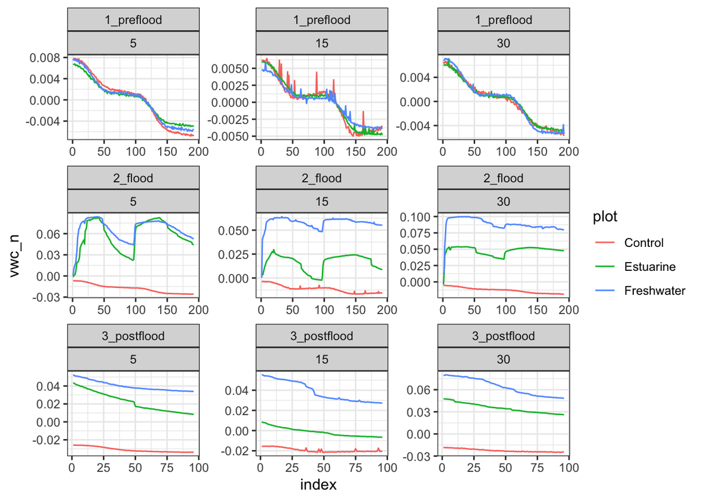

#### EC

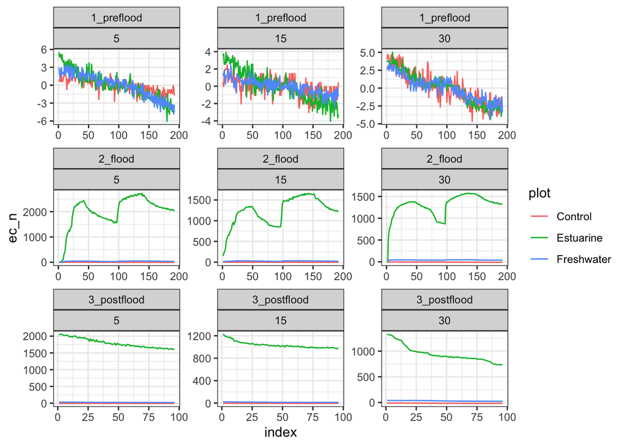

#### DO

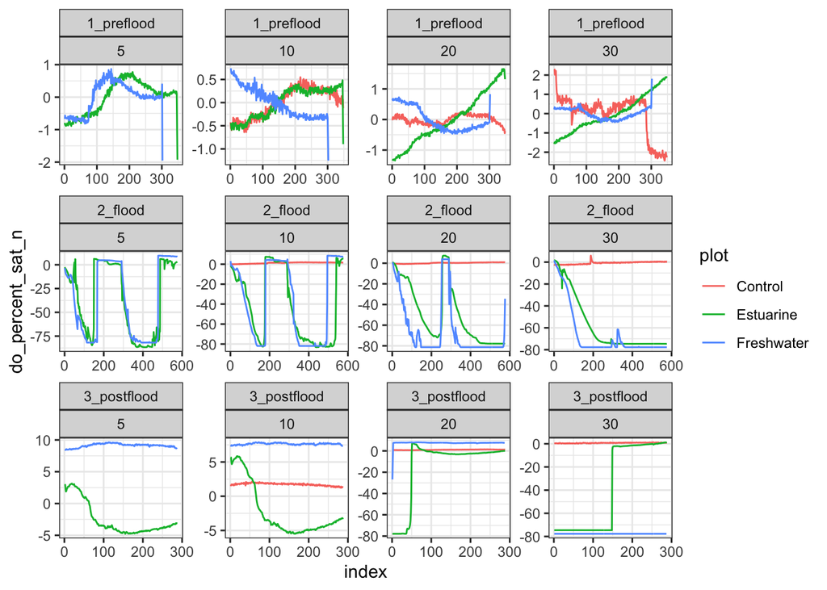

#### Eh

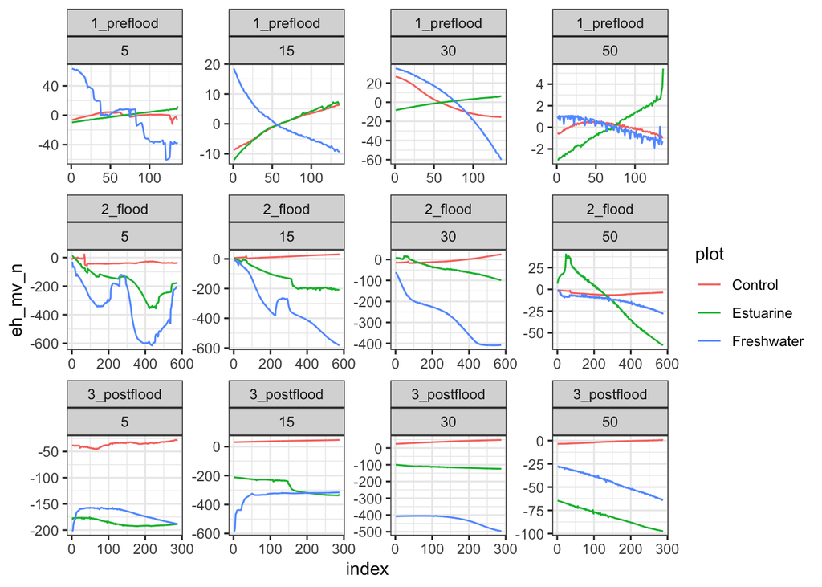

```
## Anova Table (Type 3 tests)
##
## Response: vwc_n
##   Effect           df  MSE    F   ges p.value
## 1   plot 1.11, 212.44 0.00 0.00 <.001   >.999
## ---
## Signif. codes:  0 '***' 0.001 '**' 0.01 '*' 0.05 '+' 0.1 ' ' 1
##
## Sphericity correction method: GG
```

That looks much better! Now let’s see if flooding also matches our assumption:

```
## Anova Table (Type 3 tests)
##
## Response: vwc_n
##   Effect           df  MSE           F  ges p.value
## 1   plot 1.13, 216.16 0.00 2620.19 *** .855   <.001
## ---
## Signif. codes:  0 '***' 0.001 '**' 0.01 '*' 0.05 '+' 0.1 ' ' 1
##
## Sphericity correction method: GG
```

It does. And we could be done.

### Testing assumptions

EXCEPT. We need to check normality and homogeneity of variance. Unsurprisingly, we super-duper violate these (*I’ll be presenting results with p-values on the y-axis since that’s what I’m interested in. Confusing at first, but the horizontal line is our threshold of p=0.05, so values below are significant, values above are not*):

#### Shapiro - normality

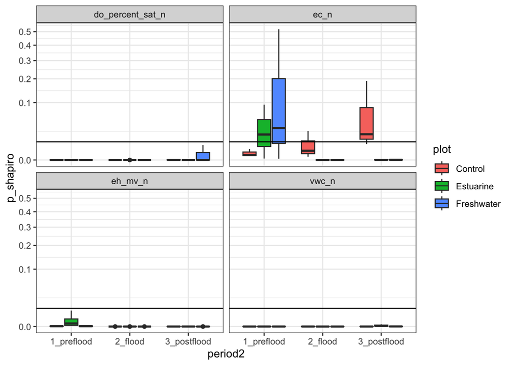

#### Levene’s - homogeneity

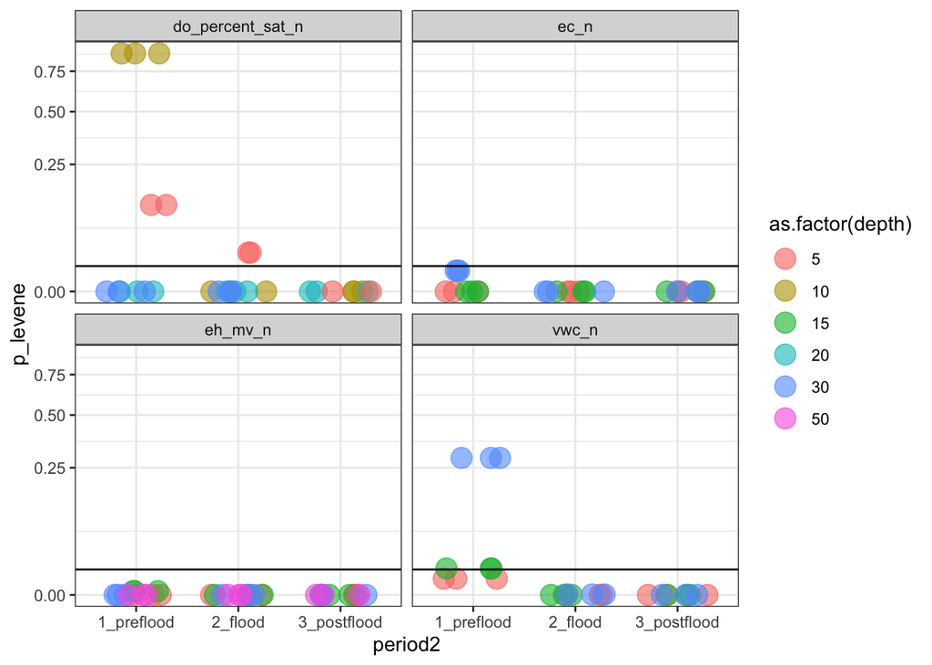

### Decision #4 - Binning

So, to reduce auto-correlation, I messed around with binning, and realized that helps to normalize distributions and also helps (a little) with homogeneity. Here is our data binned to 4-hour averages (n=12 per group except where data were not started collecting 48 hours prior (DO and Eh):

#### Shapiro - normality (binned)

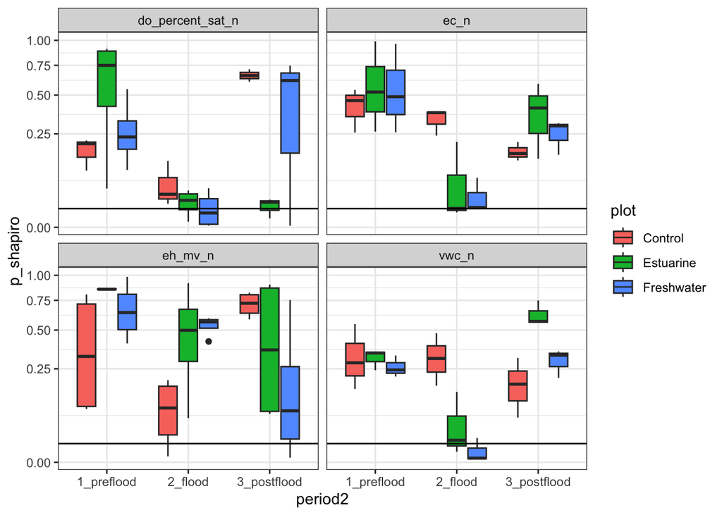

#### Levene’s - homogeneity (binned)

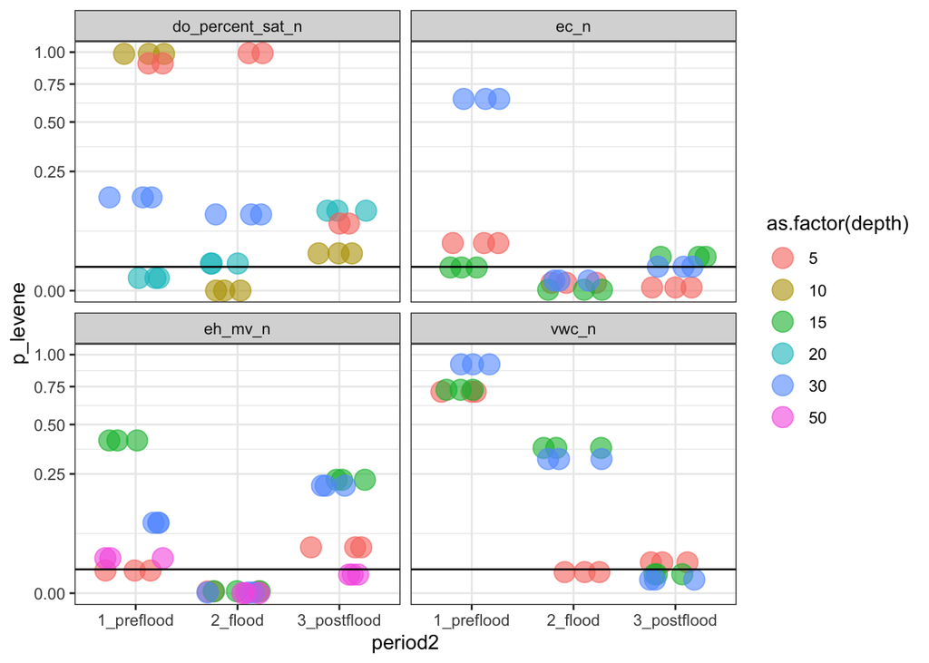

This is all an improvement, but we still are not meeting the assumption of homogeneity of variance, which makes sense, since we see very different responses between plots during flooding. For context, here’s the autocorrelation for the same dataset show above, but binned:

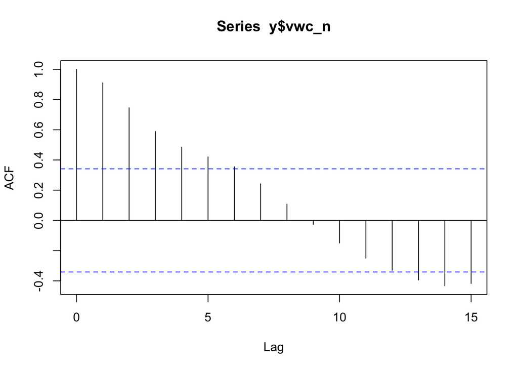

Because this looks much better, we’re going to stick with binned data for coming analyses. This may not be strictly necessary since we’re using repeated measures, but autocorrelation is my nemesis, and if we’ve got a way to reduce it, I think that’s good regardless of the statistical approach used.

So. Another fork in the road: A) dig into data normalization to find a way to neutralize homogeneity of variance, or B) find something non-parametric that’s not making that assumption.

### Decision #5 - Friedman Tests

The Friedman rank sum test is a “non-parametric alternative to the one-way repeated neasures ANOVA test”, exactly what we need.

```
## # A tibble: 42 × 4
##    variable depth period2     p_friedman
##    <chr>    <dbl> <chr>            <dbl>
##  1 vwc_n        5 1_preflood  0.368
##  2 vwc_n        5 2_flood     0.0000123
##  3 vwc_n        5 3_postflood 0.000912
##  4 vwc_n       15 1_preflood  0.794
##  5 vwc_n       15 2_flood     0.00000226
##  6 vwc_n       15 3_postflood 0.000912
##  7 vwc_n       30 1_preflood  0.926
##  8 vwc_n       30 2_flood     0.00000226
##  9 vwc_n       30 3_postflood 0.000912
## 10 ec_n         5 1_preflood  0.199
## # ℹ 32 more rows
```

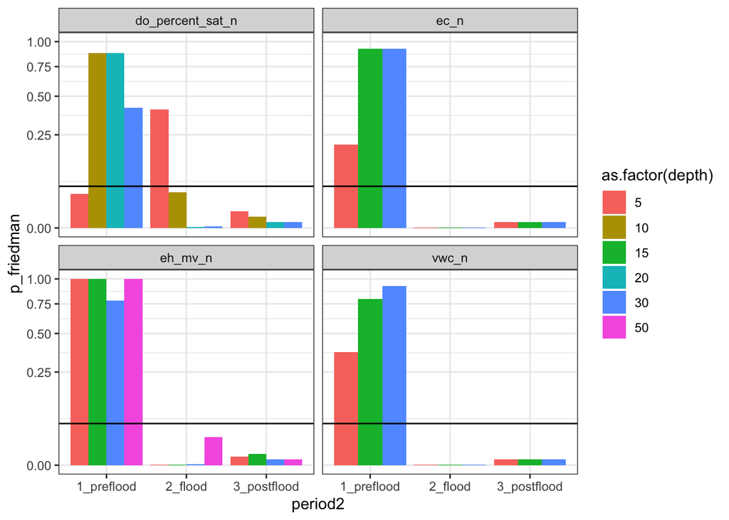

Home-stretch, let’s follow up with Post-hoc pairwise tests to confirm which combinations are significantly different for each significant Friedman result:

### Significant Wilcoxon results

#### VWC

Sample Table

| variable | depth | period2 | group1 | group2 | p_adj |
| --- | --- | --- | --- | --- | --- |
| vwc_n | 5 | 2_flood | Control | Estuarine | 6.00e-07 |
| vwc_n | 5 | 2_flood | Control | Freshwater | 6.00e-07 |
| vwc_n | 5 | 3_postflood | Control | Estuarine | 2.00e-03 |
| vwc_n | 5 | 3_postflood | Control | Freshwater | 2.00e-03 |
| vwc_n | 15 | 2_flood | Control | Estuarine | 6.00e-07 |
| vwc_n | 15 | 2_flood | Control | Freshwater | 6.00e-07 |
| vwc_n | 15 | 2_flood | Estuarine | Freshwater | 6.00e-07 |
| vwc_n | 15 | 3_postflood | Control | Estuarine | 2.00e-03 |
| vwc_n | 15 | 3_postflood | Control | Freshwater | 2.00e-03 |
| vwc_n | 15 | 3_postflood | Estuarine | Freshwater | 2.00e-03 |
| vwc_n | 30 | 2_flood | Control | Estuarine | 6.00e-07 |
| vwc_n | 30 | 2_flood | Control | Freshwater | 6.00e-07 |
| vwc_n | 30 | 2_flood | Estuarine | Freshwater | 1.12e-04 |
| vwc_n | 30 | 3_postflood | Control | Estuarine | 2.00e-03 |
| vwc_n | 30 | 3_postflood | Control | Freshwater | 2.00e-03 |
| vwc_n | 30 | 3_postflood | Estuarine | Freshwater | 2.00e-03 |

#### EC

Sample Table

| variable | depth | period2 | group1 | group2 | p_adj |
| --- | --- | --- | --- | --- | --- |
| ec_n | 5 | 2_flood | Control | Estuarine | 4.92e-05 |
| ec_n | 5 | 2_flood | Control | Freshwater | 4.92e-05 |
| ec_n | 5 | 2_flood | Estuarine | Freshwater | 2.15e-04 |
| ec_n | 5 | 3_postflood | Control | Estuarine | 2.00e-03 |
| ec_n | 5 | 3_postflood | Control | Freshwater | 2.00e-03 |
| ec_n | 5 | 3_postflood | Estuarine | Freshwater | 2.00e-03 |
| ec_n | 15 | 2_flood | Control | Estuarine | 4.92e-05 |
| ec_n | 15 | 2_flood | Control | Freshwater | 4.92e-05 |
| ec_n | 15 | 2_flood | Estuarine | Freshwater | 6.00e-07 |
| ec_n | 15 | 3_postflood | Control | Estuarine | 2.00e-03 |
| ec_n | 15 | 3_postflood | Control | Freshwater | 2.00e-03 |
| ec_n | 15 | 3_postflood | Estuarine | Freshwater | 2.00e-03 |
| ec_n | 30 | 2_flood | Control | Estuarine | 6.00e-07 |
| ec_n | 30 | 2_flood | Control | Freshwater | 6.00e-07 |
| ec_n | 30 | 2_flood | Estuarine | Freshwater | 6.00e-07 |
| ec_n | 30 | 3_postflood | Control | Estuarine | 2.00e-03 |
| ec_n | 30 | 3_postflood | Control | Freshwater | 2.00e-03 |
| ec_n | 30 | 3_postflood | Estuarine | Freshwater | 2.00e-03 |

#### DO

Sample Table

| variable | depth | period2 | group1 | group2 | p_adj |
| --- | --- | --- | --- | --- | --- |
| do_percent_sat_n | 10 | 2_flood | Control | Estuarine | 6.00e-03 |
| do_percent_sat_n | 10 | 3_postflood | Control | Freshwater | 2.00e-03 |
| do_percent_sat_n | 10 | 3_postflood | Estuarine | Freshwater | 2.00e-03 |
| do_percent_sat_n | 20 | 2_flood | Control | Estuarine | 1.10e-05 |
| do_percent_sat_n | 20 | 2_flood | Control | Freshwater | 4.89e-05 |
| do_percent_sat_n | 20 | 3_postflood | Control | Estuarine | 7.00e-03 |
| do_percent_sat_n | 20 | 3_postflood | Control | Freshwater | 2.00e-03 |
| do_percent_sat_n | 20 | 3_postflood | Estuarine | Freshwater | 2.00e-03 |
| do_percent_sat_n | 30 | 2_flood | Control | Estuarine | 2.15e-04 |
| do_percent_sat_n | 30 | 2_flood | Control | Freshwater | 1.15e-04 |
| do_percent_sat_n | 30 | 3_postflood | Control | Estuarine | 7.00e-03 |
| do_percent_sat_n | 30 | 3_postflood | Control | Freshwater | 3.00e-03 |
| do_percent_sat_n | 30 | 3_postflood | Estuarine | Freshwater | 3.00e-03 |

#### Eh

Sample Table

| variable | depth | period2 | group1 | group2 | p_adj |
| --- | --- | --- | --- | --- | --- |
| eh_mv_n | 5 | 2_flood | Control | Estuarine | 2.00e-03 |
| eh_mv_n | 5 | 2_flood | Control | Freshwater | 6.00e-07 |
| eh_mv_n | 5 | 2_flood | Estuarine | Freshwater | 4.20e-02 |
| eh_mv_n | 5 | 3_postflood | Control | Estuarine | 2.00e-03 |
| eh_mv_n | 5 | 3_postflood | Control | Freshwater | 2.00e-03 |
| eh_mv_n | 15 | 2_flood | Control | Estuarine | 6.00e-07 |
| eh_mv_n | 15 | 2_flood | Control | Freshwater | 6.00e-07 |
| eh_mv_n | 15 | 2_flood | Estuarine | Freshwater | 1.00e-02 |
| eh_mv_n | 15 | 3_postflood | Control | Estuarine | 2.00e-03 |
| eh_mv_n | 15 | 3_postflood | Control | Freshwater | 2.00e-03 |
| eh_mv_n | 30 | 2_flood | Control | Estuarine | 1.00e-02 |
| eh_mv_n | 30 | 2_flood | Control | Freshwater | 6.00e-07 |
| eh_mv_n | 30 | 2_flood | Estuarine | Freshwater | 4.10e-06 |
| eh_mv_n | 30 | 3_postflood | Control | Estuarine | 2.00e-03 |
| eh_mv_n | 30 | 3_postflood | Control | Freshwater | 2.00e-03 |
| eh_mv_n | 30 | 3_postflood | Estuarine | Freshwater | 2.00e-03 |
| eh_mv_n | 50 | 2_flood | Control | Freshwater | 1.12e-04 |
| eh_mv_n | 50 | 3_postflood | Control | Estuarine | 2.00e-03 |
| eh_mv_n | 50 | 3_postflood | Control | Freshwater | 2.00e-03 |
| eh_mv_n | 50 | 3_postflood | Estuarine | Freshwater | 2.00e-03 |

## tl;dr

1. Sensor time-series violate assumptions of independence, homogeneity of variance, and normality
2. Standard statistics (ANOVA) with adjustments (repeated measures, between plots instead of between periods) still violated the homogeneity assumption
3. Friedman Tests with repeated measures were used as a non-parametric alternative to ANOVA, followed by Wilcoxon as a non-parametric alternative for pairwise comparisons